# Last Session Recap

Published

Monday, 15/01/2024

# 1 Basic Statistical Test

In this session, several tests will be covered

1. Chi-Square Test
2. Independent t-test
3. Linear Regression
4. Logistic Regression

There will also two part, on how to conduct the tests

1. Basic, standard way
2. Using package: easier, tidier, prettier

# 2 Chi-square Test

## 2.1 Background

- test for significant relationship between two categorical variables
- test assumptions:
  - random sampling
  - independence
  - mutually exclusive
  - <20% of cell have expected count <5

## 2.2 Conduct Chi-square Test

Objective: To test whether employment status and gender had significant association

1. Import dataset `asthmads_clean.sav`

````markdown
```{r}
library(tidyverse)
library(haven)

asthmads <- read_sav("asthmads_clean.sav") %>%
  as_factor()
asthmads
```
````

| X | id | idR | Gender | Age | WorkStatus | Height | Ht_m | Weight_Pre | BMI_Pre | BMI_PreCat | PA_HW | Weight_Post | BMI_Post | BMI_PostCat | Tx1 | Tx2 | PEFR_Pre | PEFR_Post | SxWheeze_Pre | SxWheeze_Post | PS_Pre | PS_Post |
| --- | --- | --- | --- | --- | --- | --- | --- | --- | --- | --- | --- | --- | --- | --- | --- | --- | --- | --- | --- | --- | --- | --- |
| 1 | 1 | nXSw | Female | 34 | Unemployed | 179 | 1.79 | 84.2 | 26.28 | Obese | 5 | 76.7 | 23.94 | Overweight | Intervention | Drug B | 401 | 452 | No | Yes | 5 | 3 |
| 2 | 2 | yg2t | Male | 31 | Unemployed | 169 | 1.69 | 81.8 | 28.64 | Obese | 1 | 75.7 | 26.50 | Obese | Control | Placebo | 477 | 460 | No | Yes | 6 | 4 |
| 3 | 3 | QBW4 | Male | 25 | Employed | 164 | 1.64 | 88.5 | 32.90 | Obese | 1 | 84.1 | 31.27 | Obese | Intervention | Drug B | 417 | 476 | No | No | 4 | 4 |
| 4 | 4 | 2x2S | Female | 33 | Unemployed | 136 | 1.36 | 53.2 | 28.76 | Obese | 4 | 46.9 | 25.36 | Obese | Intervention | Drug A | 440 | 438 | Yes | No | 6 | 5 |
| 5 | 5 | mOnn | Male | 28 | Unemployed | 172 | 1.72 | 71.3 | 24.10 | Overweight | 2 | 63.3 | 21.40 | Normal | Control | Placebo | 488 | 509 | Yes | No | 4 | 2 |
| 6 | 6 | D3sl | Male | 33 | Unemployed | 178 | 1.78 | 87.3 | 27.55 | Obese | 0 | 82.6 | 26.07 | Obese | Intervention | Drug A | 428 | 459 | Yes | No | 4 | 2 |
| 7 | 7 | le6j | Female | 31 | Unemployed | 140 | 1.40 | 48.8 | 24.90 | Overweight | 5 | 41.9 | 21.38 | Normal | Control | Placebo | 450 | 480 | No | Yes | 5 | 5 |
| 8 | 8 | r3gC | Female | 34 | Employed | 140 | 1.40 | 49.1 | 25.05 | Obese | 2 | 43.6 | 22.24 | Normal | Control | Placebo | 393 | 431 | Yes | No | 4 | 2 |
| 9 | 9 | 3Tyt | Male | 31 | Employed | 171 | 1.71 | 60.1 | 20.55 | Normal | 1 | 54.7 | 18.71 | Normal | Intervention | Drug B | 424 | 532 | Yes | No | 4 | 4 |
| 10 | 10 | cmKF | Male | 28 | Employed | 163 | 1.63 | 93.1 | 35.04 | Obese | 1 | 86.2 | 32.44 | Obese | Control | Placebo | 405 | 405 | Yes | No | 5 | 3 |

[output cut: 140 more lines]

2. Creata Crosstabulation

````markdown
```{r}
with(asthmads, table(Gender, WorkStatus))
```
````

```
        WorkStatus
Gender   Unemployed Employed
  Female         47       17
  Male           33       53
```

**Base too (xtabs)**

````markdown
```{r}
xtabs(~ Gender + WorkStatus, asthmads)
```
````

```
        WorkStatus
Gender   Unemployed Employed
  Female         47       17
  Male           33       53
```

````markdown
```{r}
xtabs(~ Gender + WorkStatus, asthmads) %>%
  prop.table(., margin = 2)
```
````

```
        WorkStatus
Gender   Unemployed  Employed
  Female  0.5875000 0.2428571
  Male    0.4125000 0.7571429
```

**Tidyverse & Janitor**

````markdown
```{r}
library(tidyverse)
library(janitor)

asthmads %>%
  count(Gender, WorkStatus)
```
````

| Gender | WorkStatus | n |
| --- | --- | --- |
| Female | Unemployed | 47 |
| Female | Employed | 17 |
| Male | Unemployed | 33 |
| Male | Employed | 53 |

````markdown
```{r}
asthmads %>%
  count(Gender, WorkStatus) %>%
  pivot_wider(names_from = WorkStatus, values_from = n,
              values_fill = list(n = 0))
```
````

| Gender | Unemployed | Employed |
| --- | --- | --- |
| Female | 47 | 17 |
| Male | 33 | 53 |

````markdown
```{r}
asthmads %>%
  count(Gender, WorkStatus) %>%
  pivot_wider(names_from = WorkStatus, values_from = n,
              values_fill = list(n = 0)) %>%
  janitor::adorn_totals(c("row", "col"))
```
````

| Gender | Unemployed | Employed | Total |
| --- | --- | --- | --- |
| Female | 47 | 17 | 64 |
| Male | 33 | 53 | 86 |
| Total | 80 | 70 | 150 |

**Janitor (tabyl)**

````markdown
```{r}
asthmads %>%
  tabyl(Gender, WorkStatus)
```
````

| Gender | Unemployed | Employed |
| --- | --- | --- |
| Female | 47 | 17 |
| Male | 33 | 53 |

````markdown
```{r}
asthmads %>%
  tabyl(Gender, WorkStatus) %>%
  adorn_percentages("col") %>%
  adorn_pct_formatting()
```
````

| Gender | Unemployed | Employed |
| --- | --- | --- |
| Female | 58.8% | 24.3% |
| Male | 41.2% | 75.7% |

3. Conduct chi-square test with `chisq.test(_)` function

````markdown
```{r}
with(asthmads, table(Gender, WorkStatus)) %>%
  chisq.test(., correc = F)
```
````

```
    Pearson's Chi-squared test

data:  .
X-squared = 18.128, df = 1, p-value = 2.066e-05
```

## 2.3 Package `gtsummary::`

`gtsummary::` package is my favourite package, providing an elegant and flexible way to create publication-ready analytical and summary tables.

````markdown
```{r}
library(gtsummary)

asthmads %>%
  select(Gender, WorkStatus) %>%
  tbl_summary(by = WorkStatus)
```
````

| **Characteristic** | **Unemployed**, N = 80<sup>1</sup> | **Employed**, N = 70<sup>1</sup> |
| --- | --- | --- |
| Gender |  |  |
| Female | 47 (59%) | 17 (24%) |
| Male | 33 (41%) | 53 (76%) |

<sup>1</sup> n (%)

````markdown
```{r}
asthmads %>%
  select(Gender, WorkStatus) %>%
  tbl_summary(by = WorkStatus) %>%
  add_p()
```
````

| **Characteristic** | **Unemployed**, N = 80<sup>1</sup> | **Employed**, N = 70<sup>1</sup> | **p-value**<sup>2</sup> |
| --- | --- | --- | --- |
| Gender |  |  | <0.001 |
| Female | 47 (59%) | 17 (24%) |  |
| Male | 33 (41%) | 53 (76%) |  |

<sup>1</sup> n (%)  
<sup>2</sup> Pearson’s Chi-squared test

# 3 Independent t-test

## 3.1 Background

- test for significant difference of normally distributed continuous variable between two group
- test’s assumption
  - random sampling
  - independence
  - normal distributed
  - **equal variance (homoscedasticity)**

## 3.2 Conduct Independent t-test

Objective: to compare body height between gender

1. import dataset
- in this example, same dataset (i.e. asthmads) is used.
2. Confirm data distribution

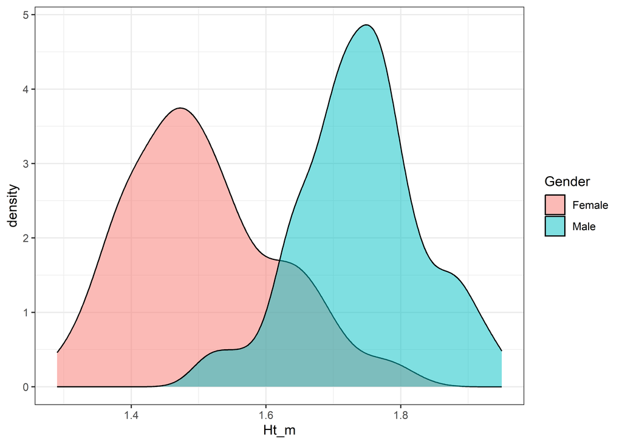

````markdown
```{r}
asthmads %>%
  ggplot(aes(x = Ht_m, fill = Gender)) +
  geom_density(alpha = .5) +
  theme_bw()
```
````

3. Calculate mean & sd of height for each gender

````markdown
```{r}
asthmads %>%
  group_by(Gender) %>%
  summarise(mean = mean(Ht_m, na.rm = T),
            sd = sd(Ht_m, na.rm = T))
```
````

| Gender | mean | sd |
| --- | --- | --- |
| Female | 1.503906 | 0.10977057 |
| Male | 1.741047 | 0.08981064 |

**summarytools**

````markdown
```{r}
asthmads %>%
  group_by(Gender) %>%
  descr(Ht_m)
```
````

```
Descriptive Statistics
Ht_m by Gender
Data Frame: asthmads
N: 64

                    Female     Male
----------------- -------- --------
             Mean     1.50     1.74
          Std.Dev     0.11     0.09
              Min     1.29     1.51
               Q1     1.42     1.69
           Median     1.48     1.74
               Q3     1.56     1.79
              Max     1.79     1.95
              MAD     0.10     0.07
              IQR     0.13     0.10
               CV     0.07     0.05
         Skewness     0.51    -0.05
      SE.Skewness     0.30     0.26
         Kurtosis    -0.28     0.03
          N.Valid    64.00    86.00
        Pct.Valid   100.00   100.00
```

**rstatix**

````markdown
```{r}
library(rstatix)

asthmads %>%
  group_by(Gender) %>%
  get_summary_stats(Ht_m)
```
````

| Gender | variable | n | min | max | median | q1 | q3 | iqr | mad | mean | sd | se | ci |
| --- | --- | --- | --- | --- | --- | --- | --- | --- | --- | --- | --- | --- | --- |
| Female | Ht_m | 64 | 1.29 | 1.79 | 1.48 | 1.428 | 1.560 | 0.133 | 0.104 | 1.504 | 0.11 | 0.014 | 0.027 |
| Male | Ht_m | 86 | 1.51 | 1.95 | 1.74 | 1.690 | 1.788 | 0.098 | 0.074 | 1.741 | 0.09 | 0.010 | 0.019 |

4. Conduct independent t-test with `t.test(_)` function

````markdown
```{r}
t.test(Ht_m ~ Gender, asthmads)
```
````

```
    Welch Two Sample t-test

data:  Ht_m by Gender
t = -14.12, df = 119.43, p-value < 2.2e-16
alternative hypothesis: true difference in means between group Female and group Male is not equal to 0
95 percent confidence interval:
 -0.2703944 -0.2038862
sample estimates:
mean in group Female   mean in group Male
            1.503906             1.741047
```

## 3.3 Package `gtsummary::`

````markdown
```{r}
library(gtsummary)

asthmads %>%
  select(Gender, Ht_m) %>%
  tbl_summary(by = Gender,
              statistic = list(all_continuous() ~ "{mean} ({sd})"))

asthmads %>%
  select(Gender, Ht_m) %>%
  tbl_summary(by = Gender,
              statistic = list(all_continuous() ~ "{mean} ({sd})")) %>%
  add_p(test = list(all_continuous() ~ "t.test"))
```
````

| **Characteristic** | **Female**, N = 64<sup>1</sup> | **Male**, N = 86<sup>1</sup> |
| --- | --- | --- |
| Ht_m | 1.50 (0.11) | 1.74 (0.09) |

<sup>1</sup> Mean (SD)

| **Characteristic** | **Female**, N = 64<sup>1</sup> | **Male**, N = 86<sup>1</sup> | **p-value**<sup>2</sup> |
| --- | --- | --- | --- |
| Ht_m | 1.50 (0.11) | 1.74 (0.09) | <0.001 |

<sup>1</sup> Mean (SD)  
<sup>2</sup> Welch Two Sample t-test

**broom**

````markdown
```{r}
library(broom)

t.test(Ht_m ~ Gender, asthmads) %>%
  tidy()
```
````

| estimate | estimate1 | estimate2 | statistic | p.value | parameter | conf.low | conf.high | method | alternative |
| --- | --- | --- | --- | --- | --- | --- | --- | --- | --- |
| -0.2371403 | 1.503906 | 1.741047 | -14.11988 | 3.155877e-27 | 119.4342 | -0.2703944 | -0.2038862 | Welch Two Sample t-test | two.sided |

**rstatix**

````markdown
```{r}
library(rstatix)

asthmads %>%
  t_test(Ht_m ~ Gender, detailed = T)
```
````

|  | estimate | estimate1 | estimate2 | .y. | group1 | group2 | n1 | n2 | statistic | p | df | conf.low | conf.high | method | alternative |
| --- | --- | --- | --- | --- | --- | --- | --- | --- | --- | --- | --- | --- | --- | --- | --- |
| 1 | -0.2371403 | 1.503906 | 1.741047 | Ht_m | Female | Male | 64 | 86 | -14.11988 | 3.16e-27 | 119.4342 | -0.2703944 | -0.2038862 | T-test | two.sided |

# 4 Linear Regression

## 4.1 Background

- test for significant relationship between independent variable (predictors) with dependent variable (outcome)
  - outcome is **numerical** variable
  - predictor can be **categorical** or **numerical**
- test’s assumptions
  - linearity between IV and DV
  - independence of error
  - normality of residual
  - homoscedascity of residual
  - no multicollinearity (multiple linear regression)

## 4.2 Conduct Linear Regression

1. import dataset `asthmads_clean.sav`
- same dataset used previously

# 5 Logistic Regression